# R Notebook : Fitt’s Law study

*Objectives* I wanted to redo the Fitt’s Law analysis with R to get more familiar with the tool. I will here only focus on the analysis of the confident interval and the interpretation I can (or cannot) make according to it.

— Loading Libraries and data

```r
library(tidyverse)

data = read.csv("data/data_all.csv",header=T)
```

— First Test : comparing my results and Cecile’s results

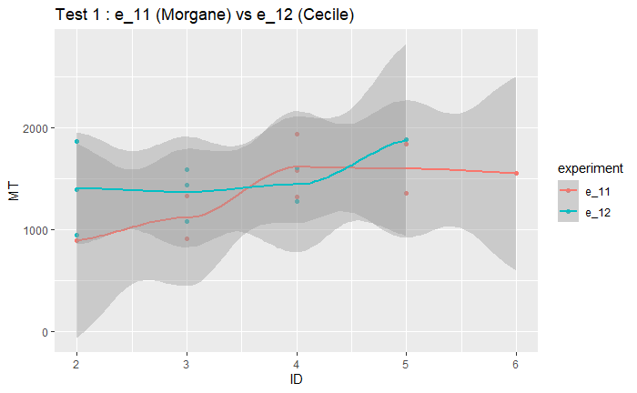

```r
library(tidyverse)


data = read.csv("data/data_all.csv",header=T)
d1 = data[(data$experiment == "e_11") | (data$experiment == "e_12"),]

ggplot(data = d1) +
  aes(x = `ID`) +
  aes(y = `MT`) +
  geom_point() +
  aes(col = `experiment`) +
  geom_smooth() +
  xlim(c(2, 6)) +
  labs(title = "Test 1 : e_11 (Morgane) vs e_12 (Cecile)")
```

We can see that the uncertainty is huge ! Maybe we should reconduct the study with more trials to be really able to compare the two results. The only thing we can see is that Cecile does have any result for ID=6, that is strange… she must have forgotten to give that results.

— Test 2 : Doubling the distance between the lines

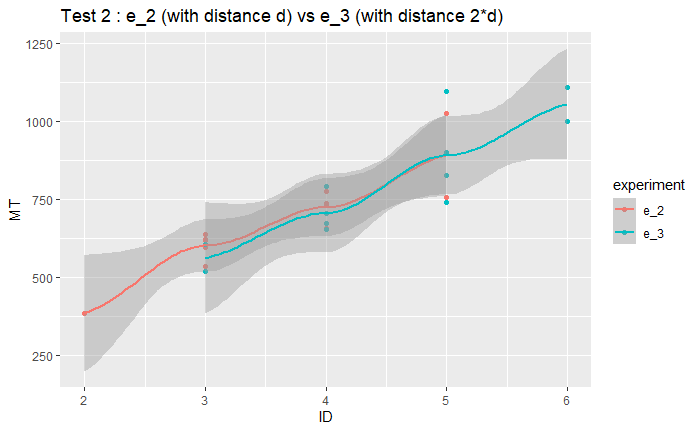

```r
d2 = data[(data$experiment == "e_2") | (data$experiment == "e_3"),]

ggplot(data = d2) +
  aes(x = `ID`) +
  aes(y = `MT`) +
  geom_point() +
  aes(col = `experiment`) +
  geom_smooth() +
  xlim(c(2, 6)) +
  labs(title = "Test 2 : e_2 (with distance d) vs e_3 (with distance 2*d)")
```

Both curves have a lot of uncertainty but they seem quite identical, except that e_3 is adding one level of difficulty compared to e_2.

— Test 3 : Mouse vs tactile pad

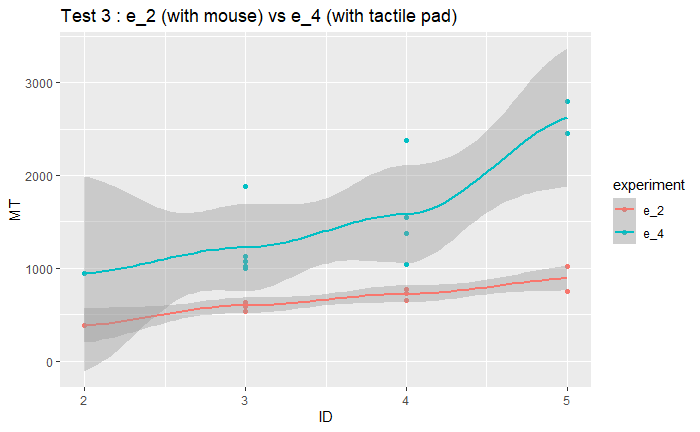

```r
d3 = data[(data$experiment == "e_2") | (data$experiment == "e_4"),]

ggplot(data = d3) +
  aes(x = `ID`) +
  aes(y = `MT`) +
  geom_point() +
  aes(col = `experiment`) +
  geom_smooth() +
  xlim(c(2, 5)) +
  labs(title = "Test 3 : e_2 (with mouse) vs e_4 (with tactile pad)")
```

We can see that the results with tactile pad are way more variable than with the mouse !

— Test 4 : normal Behavior vs safe behavior

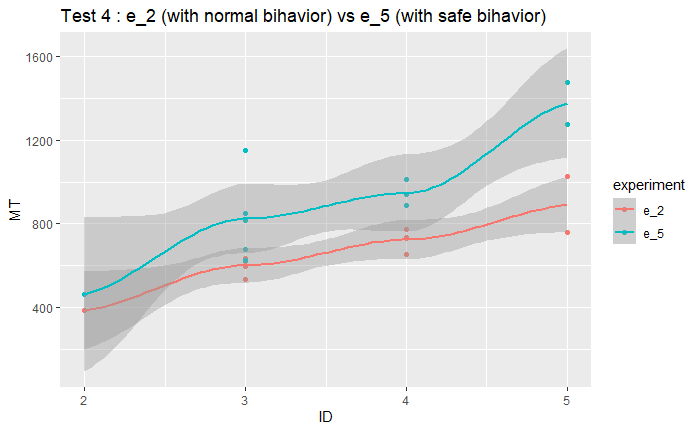

```r
d4 = data[(data$experiment == "e_2") | (data$experiment == "e_5"),]

ggplot(data = d4) +
  aes(x = `ID`) +
  aes(y = `MT`) +
  geom_point() +
  aes(col = `experiment`) +
  geom_smooth() +
  xlim(c(2, 5)) +
  labs(title = "Test 4 : e_2 (with normal bihavior) vs e_5 (with safe bihavior)")
```

We can clearly see that with a safe behavior, I took more time to execute the same task. Even with the incertainty, I am able to conclude that because the difference is clear on the graph.